# Performance of jpeglib

This notebook contains a short performance evaluation of `jpeglib` library.

**Outcome:**

- In compression `jpeglib` outperforms `cv2` and `pillow`. In decompression, `jpeglib` is faster than `pillow`, but performs similar to `cv2`.
- `torchjpeg` is faster in DCT reading than `jpeglib`, they are comparable in DCT writing.

*Experiments supporting the conclusion above used libjpeg, however measurements of performance using libjpeg-turbo were carried out as well.*

```python
import torchjpeg.codec
import jpeglib
import PIL
import cv2
```

```python
# initialize tmp directory
import os
import shutil
try: shutil.rmtree("../tmp")
except: pass
finally: os.mkdir("../tmp")
```

The timer class is implemented as an internal module of `jpeglib` already.

```python
# timer
import logging
logging.basicConfig(level=logging.WARNING)
from jpeglib import Timer
```

The DCT reading and writing are compared with `torchjpeg` library. The compression and decompression from and to RGB spatial domain is compared with `pillow` library.

For each of the four procedures, there are four test cases performed based on the processed image size.

- $64\times 64$
- $256\times 256$
- $1024\times 1024$
- $2048\times 2048$

## DCT reading

Setup procedure used in DCT reading randomly generates image spatial representation and saves it into the tmp directory.

```python
# generate random image (RGB)
import numpy as np
def generate_random_image(shape=(512,512)):
    return np.random.randint(0,255,(*shape,3))
def create_random_image_file(shape=(512,512)):
    x = generate_random_image(shape=shape)
    im = PIL.Image.fromarray(x.astype('uint8'), 'RGB')
    im.save('../tmp/image.jpg')
```

Next, we define the measurement of the libraries in reading of DCT as repetitive generating of random image and timed reading.

```python
import pandas as pd
def measure_dct_reading(shape, N=100):
    t_tj,t_tj_np,t_jl,t_jl_turbo = [],[],[],[]
    for i in range(N):

        # measure torchjpeg
        create_random_image_file(shape)
        t1 = Timer("torchjpeg")
        dimensions, qt, Y, CbCr = torchjpeg.codec.read_coefficients("../tmp/image.jpg")
        t1.stop()
        t_tj.append(t1.time)

        # measure torchjpeg with numpy conversion
        create_random_image_file(shape)
        t2 = Timer("torchjpeg w/.to_numpy()")
        dimensions, qt, Y, CbCr = torchjpeg.codec.read_coefficients("../tmp/image.jpg")
        qt   = qt.numpy()
        Y    = np.einsum('abcde->acbed', Y.numpy())
        CbCr = np.einsum('bcde->cbed', CbCr[0].numpy())
        t2.stop()
        t_tj_np.append(t2.time)

        # jpeglib
        create_random_image_file(shape)
        jpeglib.version.set('6b')
        t3 = Timer("jpeglib")
        im = jpeglib.JPEG("../tmp/image.jpg")
        Y,CbCr,qt = im.read_dct()
        t3.stop()
        t_jl.append(t3.time)

        # jpeglib w/SIMD acceleration
        create_random_image_file(shape)
        jpeglib.version.set('turbo210')
        t4 = Timer("jpeglib (turbo)")
        im = jpeglib.JPEG("../tmp/image.jpg")
        Y,CbCr,qt = im.read_dct()
        t4.stop()
        t_jl_turbo.append(t4.time)

    # collect the measurements into dataframe
    return pd.concat([
        pd.DataFrame({'library': 'torchjpeg', 'time': t_tj}),
        pd.DataFrame({'library': 'torchjpeg+to_numpy()', 'time': t_tj_np}),
        pd.DataFrame({'library': 'jpeglib', 'time': t_jl}),
        pd.DataFrame({'library': 'jpeglib (turbo)', 'time': t_jl_turbo})
    ], ignore_index=True)
```

The results of the DCT reading in the four test cases are

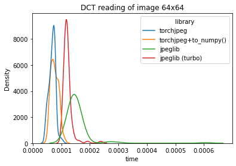

```python
import seaborn as sns
t64 = measure_dct_reading(shape=(64,64), N=100)
sns.kdeplot(data=t64, x="time", hue="library").set_title("DCT reading of image 64x64");
```

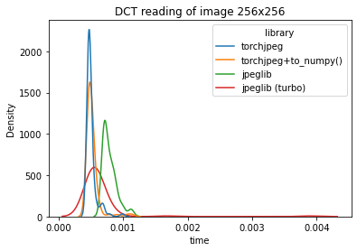

```python
t256 = measure_dct_reading(shape = (256,256), N=100)
sns.kdeplot(data=t256, x="time", hue="library").set_title("DCT reading of image 256x256");
```

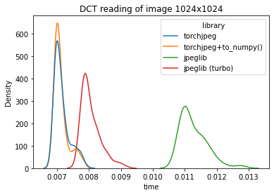

```python
t1024 = measure_dct_reading(shape = (1024,1024), N=100)
sns.kdeplot(data=t1024, x="time", hue="library").set_title("DCT reading of image 1024x1024");
```

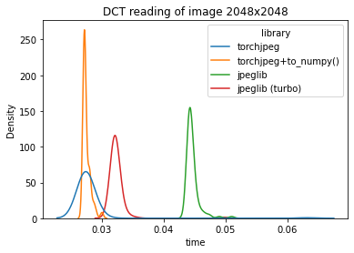

```python
t2048 = measure_dct_reading(shape = (2048,2048), N=100)
sns.kdeplot(data=t2048, x="time", hue="library").set_title("DCT reading of image 2048x2048");
```

In DCT reading, `torchjpeg` outperforms `jpeglib`, even with libjpeg-turbo used.

## DCT writing

DCT writing randomly generates luminance and chrominance matrices of DCT coefficients.

```python
# generate random Y/CbCr
import torch
def generate_random_YCbCr(shape=(512,512)):
    Y = np.random.randint(0,128,(1,int(shape[0]/8),int(shape[1]/8),8,8)).astype(np.int16)
    CbCr = np.random.randint(-63,63,(2,int(shape[0]/8/2),int(shape[1]/8/2),8,8)).astype(np.int16)
    return Y,CbCr
def generate_random_YCbCr_torch(shape=(512,512)):
    Y,CbCr = generate_random_YCbCr(shape=shape)
    return torch.from_numpy(Y),torch.from_numpy(CbCr)
```

API of `torchjpeg` requires specification of quantization matrix. The standard matrix for quality 50 is used.

```python
# standard quantization matrix for quality 50
qt50 = torch.Tensor([
    [[16,11,10,16, 24, 40, 51,61],
     [12,12,14,19, 26, 58, 60,55],
     [14,13,16,24, 40, 57, 69,56],
     [14,17,22,29, 51, 87, 80,62],
     [18,22,37,56, 68,109,103,77],
     [24,35,55,64, 81,104,113,92],
     [49,64,78,87,103,121,120,101],
     [72,92,95,98,112,100,103,99]],
    [[17,18,24,47,99,99,99,99],
     [18,21,26,66,99,99,99,99],
     [24,26,56,99,99,99,99,99],
     [47,66,99,99,99,99,99,99],
     [99,99,99,99,99,99,99,99],
     [99,99,99,99,99,99,99,99],
     [99,99,99,99,99,99,99,99],
     [99,99,99,99,99,99,99,99]],
    [[17,18,24,47,99,99,99,99],
     [18,21,26,66,99,99,99,99],
     [24,26,56,99,99,99,99,99],
     [47,66,99,99,99,99,99,99],
     [99,99,99,99,99,99,99,99],
     [99,99,99,99,99,99,99,99],
     [99,99,99,99,99,99,99,99],
     [99,99,99,99,99,99,99,99]]
]).to(torch.int16)
qt50_np = qt50.numpy()[:2]
```

The measurement of the DCT writing is similar to reading - we repeatedly generate random DCT coefficients and measure the time the writing takes.

```python
def measure_dct_writing(shape, N=100):
    t_tj,t_tj_np,t_jl,t_jl_turbo = [],[],[],[]
    dimensions = torch.Tensor([
        [shape[0],shape[1]],
        [shape[0]/2,shape[1]/2],
        [shape[0]/2,shape[1]/2]
    ]).to(torch.int32)
    for i in range(N):

        # measure torchjpeg
        Y,CbCr = generate_random_YCbCr_torch(shape)
        t1 = Timer("torchjpeg")
        torchjpeg.codec.write_coefficients('../tmp/image.jpg', dimensions, qt50, Y, CbCr)
        t1.stop()
        t_tj.append(t1.time)

        # measure torchjpeg with numpy conversion
        Y,CbCr = generate_random_YCbCr(shape)
        t2 = Timer("torchjpeg w/.from_numpy()")
        Y,CbCr = torch.from_numpy(Y),torch.from_numpy(CbCr)
        torchjpeg.codec.write_coefficients("../tmp/image.jpg", dimensions, qt50, Y, CbCr)
        t2.stop()
        t_tj_np.append(t2.time)

        # jpeglib
        Y,CbCr = generate_random_YCbCr(shape)
        jpeglib.version.set('6b')
        t3 = Timer("jpeglib")
        im = jpeglib.JPEG()
        im.write_dct("../tmp/image.jpg", Y, CbCr, qt50_np)
        t3.stop()
        t_jl.append(t3.time)

        # jpeglib w/SIMD acceleration
        Y,CbCr = generate_random_YCbCr(shape)
        jpeglib.version.set('turbo210')
        t4 = Timer("jpeglib (turbo)")
        im = jpeglib.JPEG()
        im.write_dct("../tmp/image.jpg", Y, CbCr, qt50_np)
        t4.stop()
        t_jl_turbo.append(t4.time)

    df = pd.concat([
        pd.DataFrame({'library': 'torchjpeg', 'time': t_tj}),
        pd.DataFrame({'library': 'torchjpeg+to_numpy()', 'time': t_tj_np}),
        pd.DataFrame({'library': 'jpeglib', 'time': t_jl}),
        pd.DataFrame({'library': 'jpeglib (turbo)', 'time': t_jl_turbo})
    ], ignore_index=True)
    return df
```

Test cases for writing of DCT coefficients differ based on image shapes

- $64\times 64$
- $256\times 256$
- $1024\times 1024$
- $2048\times 2048$

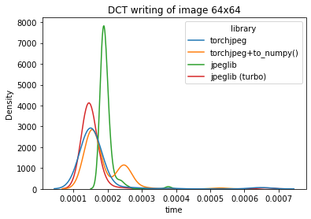

```python
t64 = measure_dct_writing(shape=(64,64), N=100)
sns.kdeplot(data=t64, x="time", hue="library").set_title("DCT writing of image 64x64");
```

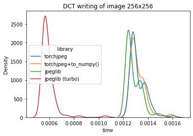

```python
t256 = measure_dct_writing(shape=(256,256), N=100)
sns.kdeplot(data=t256, x="time", hue="library").set_title("DCT writing of image 256x256");
```

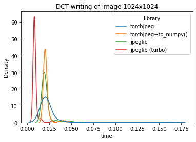

```python
t1024 = measure_dct_writing(shape=(1024,1024), N=100)
sns.kdeplot(data=t1024, x="time", hue="library").set_title("DCT writing of image 1024x1024");
```

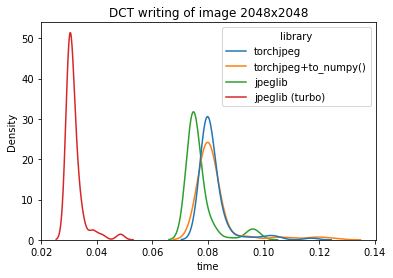

```python
t2048 = measure_dct_writing(shape=(2048,2048), N=100)
sns.kdeplot(data=t2048, x="time", hue="library").set_title("DCT writing of image 2048x2048");
```

For DCT writing, `jpeglib` and `torchjpeg` perform comparably. When using SIMD acceleration, `jpeglib` is faster.

## JPEG decompression

Next is the performance comparison in JPEG decompression between `jpeglib` and `pillow`, i.e. reading of JPEG file as RGB spatial domain.

```python
def measure_spatial_reading(shape, N=100):
    t_pil,t_cv2,t_jl,t_jl_turbo = [],[],[],[]
    for i in range(N):

        # PIL
        create_random_image_file(shape)
        t1 = Timer("pillow")
        x = np.array(PIL.Image.open("../tmp/image.jpg"))
        t1.stop()
        t_pil.append(t1.time)

        # cv2
        create_random_image_file(shape)
        t2 = Timer("cv2")
        x = cv2.imread("../tmp/image.jpg")
        t2.stop()
        t_cv2.append(t2.time)

        # jpeglib
        create_random_image_file(shape)
        jpeglib.version.set('6b')
        t3 = Timer("jpeglib")
        im = jpeglib.JPEG("../tmp/image.jpg")
        Y,CbCr,qt = im.read_dct()
        t3.stop()
        t_jl.append(t3.time)

        # jpeglib w/SIMD acceleration
        create_random_image_file(shape)
        jpeglib.version.set('turbo210')
        t4 = Timer("jpeglib (turbo)")
        im = jpeglib.JPEG("../tmp/image.jpg")
        Y,CbCr,qt = im.read_dct()
        t4.stop()
        t_jl_turbo.append(t4.time)

    # collect the measurements into dataframe
    return pd.concat([
        pd.DataFrame({'library': 'PIL', 'time': t_pil}),
        pd.DataFrame({'library': 'cv2', 'time': t_cv2}),
        pd.DataFrame({'library': 'jpeglib', 'time': t_jl}),
        pd.DataFrame({'library': 'jpeglib (turbo)', 'time': t_jl_turbo})
    ], ignore_index=True)
```

The results for the four test cases are

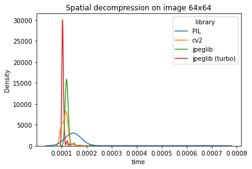

```python
t64 = measure_spatial_reading(shape=(64,64), N=100)
sns.kdeplot(data=t64, x="time", hue="library").set_title("Spatial decompression on image 64x64");
```

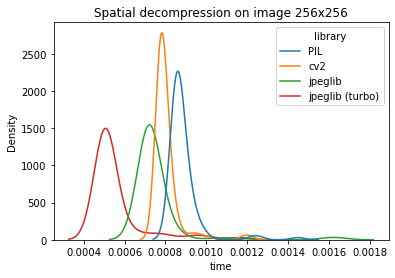

```python
t256 = measure_spatial_reading(shape=(256,256), N=100)
sns.kdeplot(data=t256, x="time", hue="library").set_title("Spatial decompression on image 256x256");
```

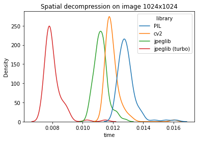

```python
t1024 = measure_spatial_reading(shape=(1024,1024), N=100)
sns.kdeplot(data=t1024, x="time", hue="library").set_title("Spatial decompression on image 1024x1024");
```

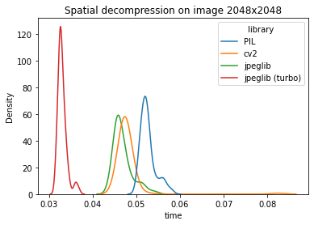

```python
t2048 = measure_spatial_reading(shape=(2048,2048), N=100)
sns.kdeplot(data=t2048, x="time", hue="library").set_title("Spatial decompression on image 2048x2048");
```

## JPEG compression

Next is the performance comparison in JPEG compression between `jpeglib` and `pillow`, i.e. writing RGB spatial domain to JPEG file.

```python
def measure_spatial_writing(shape, N=100):
    t_pil,t_cv2,t_jl,t_jl_turbo = [],[],[],[]
    for i in range(N):

        # PIL
        x = generate_random_image(shape)
        t1 = Timer("pillow")
        im = PIL.Image.fromarray(x.astype('uint8'), 'RGB')
        im.save("../tmp/image.jpg")
        t1.stop()
        t_pil.append(t1.time)

        # cv2
        x = generate_random_image(shape)
        t2 = Timer("cv2")
        x = cv2.imwrite("../tmp/image.jpg", x)
        t2.stop()
        t_cv2.append(t2.time)

        # jpeglib
        x = generate_random_image(shape)
        jpeglib.version.set('6b')
        t3 = Timer("jpeglib")
        im = jpeglib.JPEG()
        im.write_spatial("../tmp/image.jpg", x)
        t3.stop()
        t_jl.append(t3.time)

        # jpeglib w/SIMD acceleration
        generate_random_image(shape)
        jpeglib.version.set('turbo210')
        t4 = Timer("jpeglib (turbo)")
        im = jpeglib.JPEG()
        im.write_spatial("../tmp/image.jpg", x)
        t4.stop()
        t_jl_turbo.append(t4.time)

    # collect the measurements into dataframe
    return pd.concat([
        pd.DataFrame({'library': 'PIL', 'time': t_pil}),
        pd.DataFrame({'library': 'cv2', 'time': t_cv2}),
        pd.DataFrame({'library': 'jpeglib', 'time': t_jl}),
        pd.DataFrame({'library': 'jpeglib (turbo)', 'time': t_jl_turbo})
    ], ignore_index=True)
```

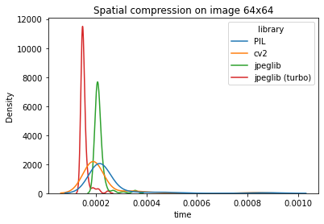

```python
t64 = measure_spatial_writing(shape=(64,64), N=100)
sns.kdeplot(data=t64, x="time", hue="library").set_title("Spatial compression on image 64x64");
```

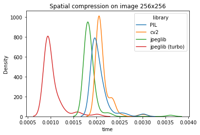

```python
t256 = measure_spatial_writing(shape=(256,256), N=100)
sns.kdeplot(data=t256, x="time", hue="library").set_title("Spatial compression on image 256x256");
```

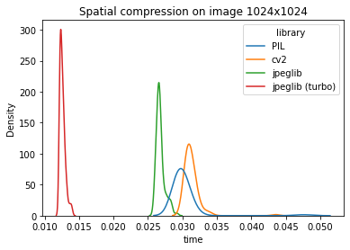

```python
t1024 = measure_spatial_writing(shape=(1024,1024), N=100)
sns.kdeplot(data=t1024, x="time", hue="library").set_title("Spatial compression on image 1024x1024");
```

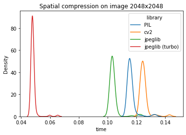

```python
t2048 = measure_spatial_writing(shape=(2048,2048), N=100)
sns.kdeplot(data=t2048, x="time", hue="library").set_title("Spatial compression on image 2048x2048");
```

Amongst `pillow`, `cv2` and `jpeglib` in JPEG compression, `jpeglib` is the fastest.

## Cleanup

```python
# cleanup
shutil.rmtree("../tmp")
```